# Midterm

Your name here

# Dependencies

```r
library(dplyr)
library(randomForest) # or any other random forest/boosting/ML library of your choice
#library(patchwork)
library(ggplot2)
library(hrbrthemes)
```

# 1 Question 1

Firstly I would convince my manager that the correct way to approach this problem is through Regression analysis for the following reasons:

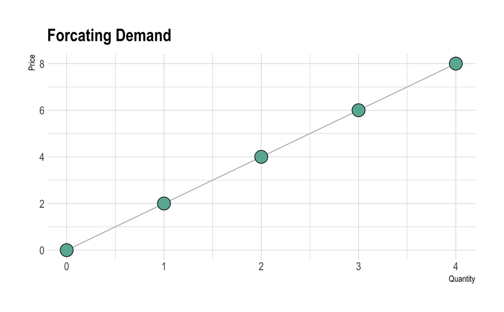

• Machine learning is used to predict outcomes that is finding a good fit of y_hat to y on same distribution and therefore here ml model might overfit • Machine learning model will not good in getting consistent stable estimators that is qty demanded in repeated sampling • The danger in using ML algorithm would be these tools are taking an algorithm built for y_hat, and presuming their β_hat have the properties we typically associate with estimation output • Machine learning is used when the data is non-linearly related and to predict rather than estimating

I use machine learning algorithms instead of statistical regression when: • The goal is to predict rather than explain and there are a lots of predictor variables • There is a correlation or interaction between the predictor variables • There is a non- liner relationship between the X and Y

Since there are very few X variables using ML would have biased results.

# 2 Question 2

• A parameter can be defined as values that are internal to the model and the learning algorithm can change these values independently as it and and these values are affected by the choice of hyperparameters you provide

• Non parametric model differ from parametric model in the terms that the model structure is not specified a prior but it is determined by data. • With the random forest there are no assumptions about the distribution of the error of the data. • It means that the model is constructed based on the observed data. • It totally depends on how the tree purning is done if splitting is done on the sample size for example split the node if has more than 20 data points then the Random forest would be non parametric • Of course the tree depth is a parameter of the algorithm, but it is not innternally derived from the data, but rather an input parameter that has to be provided by the user.

• For OLS the number of parameter are fixed with respect to the sample size. In an OLS regression, the number of parameters will always be the length of 𝛽, plus one for the variance.

## 2.1 When is one better than the other? Be very specific.

• A non-parametric model can be used when our focus is predicting that is if our goal is to achieve a model with higher prediction accuracy one should use non-linear prediction models like bagging,boosting, random forest etc. Non- parametric models are time consuming and computaionally costly. They are mojorly used when the data is categorical. Often nonparametric methods will be used when the population data has an unknown distribution, or when the sample size is small.Here the parameter are flexible

• A parametric model can be used when our goal is to make a better inference that is answering the why behind a question. Here we can use non parametric models like lasso regression, linear regression etc which have high interpretability. The most common assumption of a parametic model is normal distribution.Here the parameter are fixed.

# 3 Question 3

• To define the random forest in a layman’s language random forest builds multiple decision tree and merge them together to get an accurate and stable prediction. • The logic here is multiple uncorrelated model perform better than a correlated model that is there could be low correlation or no correlation between individual model or a decision tree that make up the Random Forest. While, individual tree may produce errors, the majority of the group will be trees will be correct therefore moving on to an outcome that is more precise. • When using Random forest for classification model each tree gives a value or vote the model chooses the value with maximum votes • For a regression model the forest picks up the average output of all the trees # Is cross validation needed? Since each tree is constructed using a completely different bootstrap data from the original data set a cross validation is not needed to get an unbiased estimates. It is estimated internally during the run.

# 4 Question 4

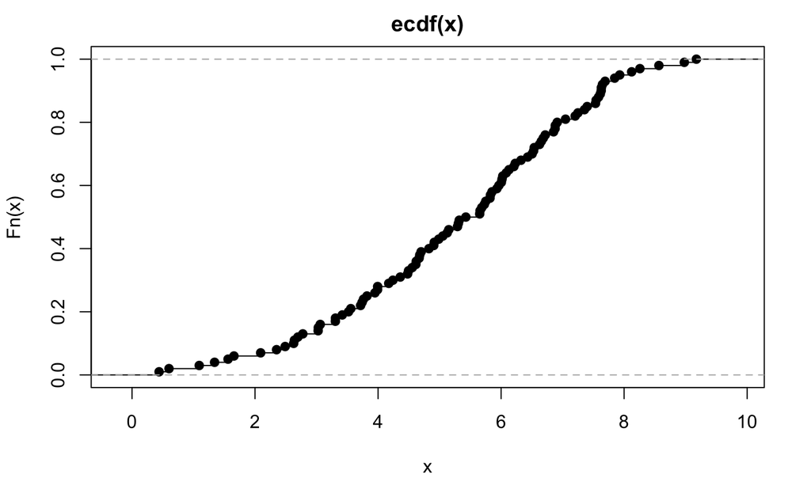

```r
n=1e2
x = rnorm(n=n, mean = 5, sd = 2)
plot(ecdf(x))
```

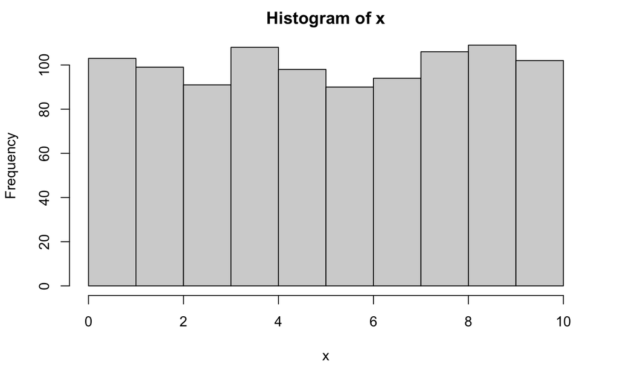

```r
n = 1e3
x= runif(n=1e3,min=0,max=10)
hist(x)
```

```r
n= 5e3
x=rbinom(n=n,size=1,prob=0.75)

# confirm your coin is unfair based on the 500 flips.
mean(x)
```

```
[1] 0.7422
```

# 5 Question 5

```r
n = 1e3
k= 3
epsilon= rnorm(n=n, mean=0,sd=1)
#Setting up a matrix of generates data with mean 10 and sd = 2
X5 = matrix(data = rnorm(n = n*k, mean =  10, sd = 2), ncol = k, nrow = n)
Y5 = 1 + 2*X5[,1]+ 3*X5[,2] +-5*X5[,3]+epsilon
#Adding X and Y in a data frame
df_l= data.frame(X5,Y5)
df_l
```

| X1 | X2 | X3 | Y5 |
| --- | --- | --- | --- |
| 10.619196 | 13.351490 | 8.208028 | 19.97347216 |
| 10.848019 | 9.415207 | 7.901918 | 10.65585783 |
| 10.775605 | 8.565018 | 7.877255 | 8.28273055 |
| 6.269588 | 8.507967 | 8.247367 | -2.95033063 |
| 9.183072 | 10.504708 | 9.551417 | 2.71106414 |
| 9.146859 | 9.980233 | 10.569680 | -3.99213951 |
| 8.770724 | 10.577170 | 11.302224 | -6.36687158 |
| 12.597552 | 9.629694 | 7.724542 | 16.98006346 |
| 10.745416 | 9.249082 | 11.874773 | -9.07357775 |
| 12.503789 | 9.160011 | 7.823106 | 15.27367793 |

[output cut: 990 more lines]

[output not shown]

[output cut: 270 more lines]

```r
#writing a funtion for ols
m_ols5 = lm(Y5 ~ . -train, data = df_l_train)
yhat_ols5 = predict(object = m_ols5, newdata = df_l_test)
error_ols5 = yhat_ols5 - df_l_test$Y5
sqrt(mean(error_ols5^2))
```

```
[1] 1.02679
```

```r
m_rf5 = randomForest(Y5 ~ . -train, data = df_l_train)
yhat_rf5 = predict(object = m_rf5, newdata = df_l_test)
error_rf5 = yhat_rf5 - df_l_test$Y5
sqrt(mean(error_rf5^2))
```

```
[1] 2.320751
```

# 6 Question 6

Given both the method above ols does well as it has a low mean squared because the variable X and Y have liner relation and also because the are independent of the number of traning instances. # Question 7

```r
n7 =1e3
k7 = 5
X7  = matrix(data = rnorm(n7 * k7, mean=10,sd = 2), nrow = n7, ncol = k7)
epsilon7 =  rnorm(n=n, mean=0,sd=1)
y7 = 1 + 3*sin(X7[,1]/2) + 15*cos(pi*X7[,2]) + X7[,3]^4 + X7[,4]^2+ 5*tan(X7[,5]) + epsilon7
df_nl_md = data.frame(y7,X7)
df_nl_md
```

| y7 | X1 | X2 | X3 | X4 | X5 |
| --- | --- | --- | --- | --- | --- |
| 11851.4334 | 11.352837 | 10.020956 | 10.415730 | 9.032521 | 8.231958 |
| 17875.6382 | 7.809507 | 11.086942 | 11.552586 | 8.856960 | 12.382218 |
| 6646.1153 | 8.002061 | 11.400966 | 8.998079 | 9.974288 | 8.949060 |
| 19339.6783 | 11.558843 | 7.274982 | 11.780138 | 9.929035 | 11.586410 |
| 23871.8104 | 10.329249 | 12.183532 | 12.416735 | 9.553062 | 9.366949 |
| 12290.8557 | 7.999962 | 9.295913 | 10.500205 | 12.060971 | 6.423912 |
| 14380.8280 | 8.754345 | 10.276708 | 10.930322 | 10.346880 | 8.461297 |
| 1514.2319 | 9.396305 | 5.445572 | 6.125900 | 10.784163 | 11.690320 |
| 1876.5374 | 11.023554 | 9.565083 | 6.458868 | 11.695194 | 11.972279 |
| 3105.2966 | 10.502910 | 12.407671 | 7.410469 | 8.486806 | 13.802764 |

[output cut: 990 more lines]

```r
df_nl_md$ train = sample(x = c(0,1), size = nrow(df_nl_md), replace = T, prob = c(0.3, 0.7))
df_nl_md_train = subset(df_nl_md, train == 1)
df_nl_md_test = subset(df_nl_md, train == 0)
```

```r
m_ols7 = lm(y7 ~ . -train, data = df_nl_md_train)
yhat_ols7 = predict(object = m_ols7, newdata = df_nl_md_test)
error_ols7 = yhat_ols7 - df_nl_md_test$y7
sqrt(mean(error_ols7^2))
```

```
[1] 2958.128
```

```r
m_rf7 = randomForest(y7 ~ . -train, data = df_nl_md_train)
yhat_rf7 = predict(object = m_rf7, newdata = df_nl_md_test)
error_rf7 = yhat_rf7 - df_nl_md_test$y7
sqrt(mean(error_rf7^2))
```

```
[1] 2442.351
```

```r
#Random Forest performs better on a non-liner data set
```

# 7 Question 8

Random forest learns the data generating process by creating multiple decision tree on the training set. It uses bagging and feature randomness while building these individual tree that helps not only in creating an uncorrelated forest of trees but also helps the model to learn the data. Therefore, prediction by Random Forest is more accurate than an indivuidal tree.

```r
n2 =1e3
k2 = 5
X2  = matrix(data = rnorm(n2 * k2,mean = 20, sd= 4), nrow = n2, ncol = k2)
epsilon2 =rnorm(n=n, mean=0,sd=1)
y2 = 1 + 3*sin(X2[,1]/2) + 15*cos(pi*X2[,2]) + X2[,3]^4 + X2[,4]^2+ 5*tan(X2[,5]) + epsilon2
df_novel = data.frame(X2,y2)
names(df_novel)[names(df_novel)=='y2'] <- 'y7'
df_novel
```

| X1 | X2 | X3 | X4 | X5 | y7 |
| --- | --- | --- | --- | --- | --- |
| 23.467032 | 24.803609 | 13.799333 | 19.900092 | 17.832829 | 36634.453 |
| 17.556620 | 18.072931 | 24.341610 | 15.339961 | 23.090659 | 351334.038 |
| 10.583344 | 21.020393 | 24.583989 | 20.695245 | 22.103719 | 365679.567 |
| 18.041697 | 21.158974 | 16.505154 | 21.938389 | 18.995134 | 74685.300 |
| 21.917506 | 14.565237 | 24.441728 | 22.120155 | 18.984097 | 357368.767 |
| 16.341308 | 20.535807 | 23.216046 | 19.648909 | 20.251997 | 290920.917 |
| 19.435882 | 14.018060 | 10.927744 | 21.969827 | 17.529161 | 14737.370 |
| 18.967030 | 17.945794 | 14.423031 | 24.965737 | 19.888303 | 43921.428 |
| 14.675028 | 15.702137 | 22.952303 | 12.761026 | 17.330212 | 277606.971 |
| 21.209384 | 21.739585 | 22.474466 | 15.197220 | 23.168000 | 255379.965 |

[output cut: 990 more lines]

```r
df_novel$ train = sample(x = c(0,1), size = nrow(df_novel), replace = T, prob = c(0.3, 0.7))
df_novel_train = subset(df_novel, train == 1)
df_novel_test = subset(df_novel, train == 0)
```

```r
m_ols_n = lm(y7 ~ . -train, data = df_novel_train)
yhat_ols_n = predict(object = m_ols_n, newdata = df_novel_test)
error_ols_n = yhat_ols_n - df_novel_test$y7
sqrt(mean(error_ols_n^2))
```

```
[1] 49114.13
```

```r
m_rf_n = randomForest(y7 ~ . -train, data = df_novel_train)
yhat_rf_n = predict(object = m_rf_n, newdata = df_novel_test)
error_rf_n = yhat_rf_n - df_novel_test$y7
sqrt(mean(error_rf_n^2))
```

```
[1] 48357.24
```

```r
k = 3

simulate_experiment = function(n, tau , linear )
  {
  epsilon= rnorm(n=n, mean=0,sd=1)
  x  = matrix(data = rnorm(n * k,mean = 0, sd=1), nrow = n, ncol = k)

  if(linear==TRUE){
    w = rbinom(n = n, size = 1, prob = (1 /(1+exp(x[,3]))))
    Y= x[,1]+x[,2]+x[,3]+tau*w+epsilon }

  else if (linear != TRUE) {
    w = rbinom(n = n, size = 1, prob = ((1+sin(x[,1])*cos(x[,2]))/2))
    Y = x[,2]^3 + sin(x[,3]) + pmax(x[,1],0) + x[,3]*x[,2] + tau*w + epsilon
  }
  a = data.frame(Y,x,w,linear,tau)

  return(a)
}
```

```r
sim_exp = simulate_experiment(n = 1e5, tau = 3, linear = TRUE)
sim_exp
```

| Y | X1 | X2 | X3 | w | linear | tau |
| --- | --- | --- | --- | --- | --- | --- |
| 1.53317135 | 0.0564531255 | 0.481597200 | -1.659883350 | 1 | TRUE | 3 |
| 2.73324891 | 1.8290106067 | -1.034866675 | -0.949742078 | 1 | TRUE | 3 |
| -2.18752480 | -0.1105602381 | -0.596219846 | -0.542969208 | 0 | TRUE | 3 |
| -0.08284384 | 0.1973967390 | -1.905886376 | -0.929231664 | 0 | TRUE | 3 |
| 0.28424845 | -0.1070794979 | -0.696228590 | -1.565485913 | 1 | TRUE | 3 |
| 1.58425692 | -0.6835156868 | 0.157581710 | -0.939232198 | 1 | TRUE | 3 |
| -0.26402930 | -0.7714433234 | 0.050413042 | 1.366557339 | 0 | TRUE | 3 |
| 0.66297471 | -1.1590334771 | -0.279734722 | -1.257477918 | 1 | TRUE | 3 |
| -2.48160127 | -0.6511561098 | -2.115517023 | -0.031030256 | 0 | TRUE | 3 |
| 0.67873534 | -0.0090587702 | 0.816846263 | -0.048477067 | 0 | TRUE | 3 |

[output cut: 990 more lines]

# 8 Question 10

```r
simulated_ate = function(sample_data,method =  c('ols','machine_learning')) {

    if (method=='ols') {
      # extracting tau from liner model
      return (lm( formula = Y ~ .-linear -tau ,data = sample_data)%>% coef() %>% .[5])
      # computing tau_hat for ML model
      } else  (method=='machine_learning')
    {
      mu1 = randomForest(formula = Y ~ .-linear -tau ,data = sample_data %>% filter(w==1))
      mu1_hat= predict(mu1, newdata = sample_data)
      mu0 = randomForest(formula = Y ~ .-linear -tau ,data = sample_data %>% filter(w==0))
      mu0_hat= predict(mu0, newdata = sample_data)

      return (mean(mu1_hat - mu0_hat))
    }
}
```

```r
simulated_ate(sim_exp , method = 'ols')
```

```
       w
3.009849
```

# 9 Question 11

```r
monte_carlo_ate = function(data,sample_size,method,n_sims)
{
    df_list=  vector(mode='list',length=length(sample_size))
    for( i in seq_along(df_list))
    {
      tau_hats = vector("double", length = n_sims)
      for(j in seq_along(tau_hats))
      {
        tau_hats[j] = data %>% slice_sample(n = sample_size[i]) %>% simulated_ate(method=method)

      }
      df_return = data.frame('sample_size' = sample_size[i], 'tau_hat' = tau_hats, 'method'=method, linear= data$linear, tau = data$tau)
      df_list[[i]] = df_return
    }
    df_list = bind_rows(df_list)
    return(df_list)
}
```

```r
fun= (monte_carlo_ate(sim_exp,c(100, 500, 1000,2000),'ols', 100 ))
fun
```

| sample_size | tau_hat | method | linear | tau |
| --- | --- | --- | --- | --- |
| 100 | 3.110251 | ols | TRUE | 3 |
| 100 | 3.063535 | ols | TRUE | 3 |
| 100 | 2.958821 | ols | TRUE | 3 |
| 100 | 3.003362 | ols | TRUE | 3 |
| 100 | 3.208460 | ols | TRUE | 3 |
| 100 | 2.511758 | ols | TRUE | 3 |
| 100 | 2.799457 | ols | TRUE | 3 |
| 100 | 2.913436 | ols | TRUE | 3 |
| 100 | 3.038309 | ols | TRUE | 3 |
| 100 | 2.952413 | ols | TRUE | 3 |

[output cut: 990 more lines]

# 10 Question 12

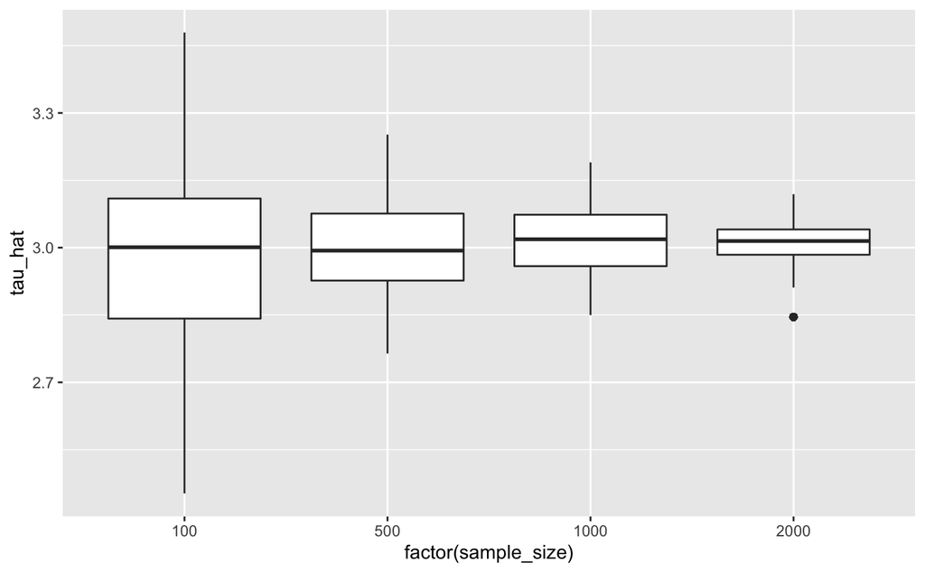

```r
fun %>% ggplot(aes(x = factor(sample_size), y=tau_hat)) +
  geom_boxplot()
```

# 11 Question 13

```r
fun2= (monte_carlo_ate(sim_exp,c(100, 500, 1000,2000),'ml', 100 ))
fun2
```

| sample_size | tau_hat | method | linear | tau |
| --- | --- | --- | --- | --- |
| 100 | 2.438148 | ml | TRUE | 3 |
| 100 | 2.518681 | ml | TRUE | 3 |
| 100 | 2.293297 | ml | TRUE | 3 |
| 100 | 3.411939 | ml | TRUE | 3 |
| 100 | 2.426370 | ml | TRUE | 3 |
| 100 | 2.215648 | ml | TRUE | 3 |
| 100 | 2.076601 | ml | TRUE | 3 |
| 100 | 2.422369 | ml | TRUE | 3 |
| 100 | 2.208857 | ml | TRUE | 3 |
| 100 | 2.936111 | ml | TRUE | 3 |

[output cut: 990 more lines]

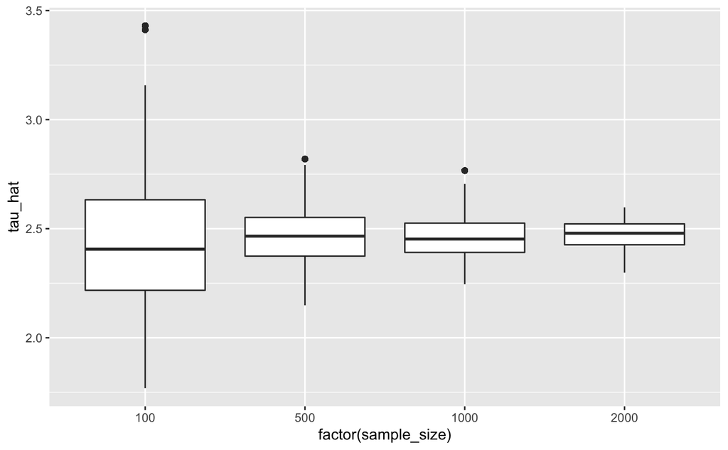

```r
fun2 %>% ggplot(aes(x = factor(sample_size), y=tau_hat)) +
  geom_boxplot()
```

# 12 Question 14

The distribution of tau_hat for an ols aligns toward the median for all the box plots and looks consistent and unbiased.

The advantages and disadvantages of the parametric model that I learned after simulating data is

Benefits: Parametric model It requires less computational efforts The results and the logic is easier to interpret and understand It is faster when it comes to learning from data Works well even on small data sets Parameters are independent of the number of training instances

Non Parametric model They learn more on the training data as compared to Parametric Model Have many parameters and hyperparameters that can be tuned very easily Computationally rich and has a better accuracy if the data is non liner

Disadvantages: Parametric model The parametric method is restrictive Don’t perform that well on less complicated algorith

Non-Parametric model

They sometimes tend to overfit the data They are computationally expensive and time consuming Slower to train Require a lot of data.